# Data Visualization

### Indonesia

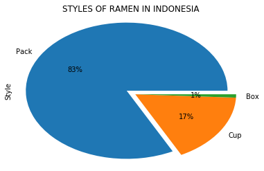

```python
#Styles of ramen in Indonesia
indonesia = rf[rf.Country == "Indonesia"]
style_indonesia = indonesia.Style.value_counts()
style_indonesia.plot.pie(explode=(0.1,0,0),autopct="%1.0f%%")
plt.axis("tight")
plt.title("STYLES OF RAMEN IN INDONESIA")
```

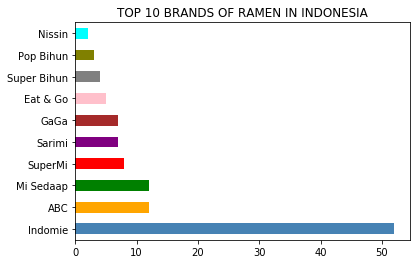

```python
#Top 10 brands of ramen in Indonesia
brand_indonesia = indonesia.Brand.value_counts().head(10)
brand_indonesia.plot.barh(color=["steelblue", "orange", "green", "red", "purple", "brown", "pink", "gray", "olive", "cyan"])
plt.title("TOP 10 BRANDS OF RAMEN IN INDONESIA")
```

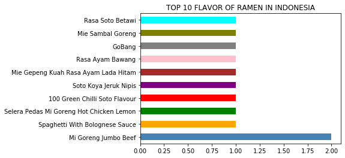

```python
#Top 10 flavor of ramen in Indonesia
variety_indonesia = indonesia.Variety.value_counts().head(10)
variety_indonesia.plot.barh(color=["steelblue", "orange", "green", "red", "purple", "brown", "pink", "gray", "olive", "cyan"])
plt.title("TOP 10 FLAVOR OF RAMEN IN INDONESIA")
```

### Singapore

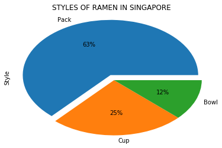

```python
#Styles of ramen in Singapore
singapore = rf[rf.Country == "Singapore"]
style_singapore = singapore.Style.value_counts()
style_singapore.plot.pie(explode=(0.1,0,0),autopct="%1.0f%%")
plt.axis("tight")
plt.title("STYLES OF RAMEN IN SINGAPORE")
```

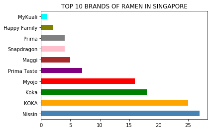

```python
#Top 10 brands of ramen in Singapore
brand_singapore = singapore.Brand.value_counts().head(10)
brand_singapore.plot.barh(color=["steelblue", "orange", "green", "red", "purple", "brown", "pink", "gray", "olive", "cyan"])
plt.title("TOP 10 BRANDS OF RAMEN IN SINGAPORE")
```

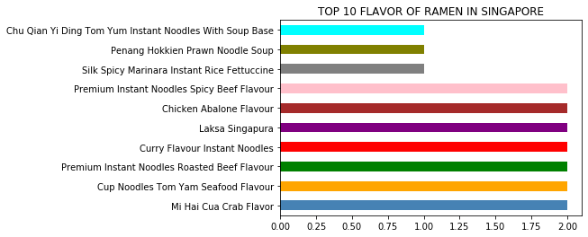

```python
#Top 10 flavor of ramen in Singapore
variety_singapore = singapore.Variety.value_counts().head(10)
variety_singapore.plot.barh(color=["steelblue", "orange", "green", "red", "purple", "brown", "pink", "gray", "olive", "cyan"])
plt.title("TOP 10 FLAVOR OF RAMEN IN SINGAPORE")
```

### Intergration

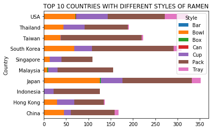

```python
# Top 10 countries with different styles
style = rf.groupby("Country")["Style"]
style = style.value_counts().unstack()
top = style[style.sum(axis=1) > 108]
top.plot.barh(stacked = True)
plt.title("TOP 10 COUNTRIES WITH DIFFERENT STYLES OF RAMEN")
```

## Global Demand

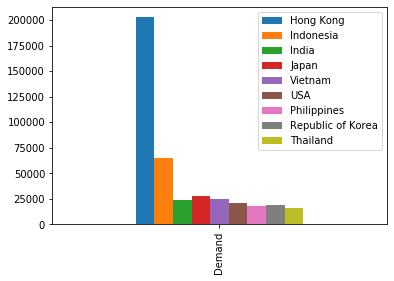

```python
#Create a new dataset for top 10 countries with highest ramen demand
demand = {"Hong Kong": 202570.0, "Indonesia":64800.0, "India":24350.0, "Japan":28140.0, "Vietnam":24980.0, "USA":20990.0, "Philippines":17940.0, "Republic of Korea":18630.0, "Thailand":16350.0}
de = pd.DataFrame(demand, index=["Demand"])
de.plot.bar()
```

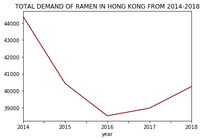

```python
#Total demand in Hong Kong
year = ["2014","2015","2016","2017","2018"]
demand = [44400, 40430, 38520, 38970, 40250]
hongkong = pd.DataFrame({"year": year, "demand": demand})
hongkong.set_index("year")["demand"].plot(color="maroon")
plt.title("TOTAL DEMAND OF RAMEN IN HONG KONG FROM 2014-2018")
```

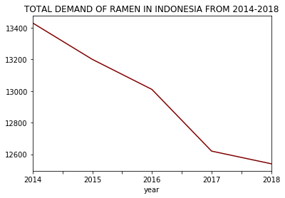

```python
#Total demand in Indonesia
year = ["2014","2015","2016","2017","2018"]
demand = [13430, 13200, 13010, 12620, 12540]
indonesia = pd.DataFrame({"year": year, "demand": demand})
indonesia.set_index("year")["demand"].plot(color="maroon")
plt.title("TOTAL DEMAND OF RAMEN IN INDONESIA FROM 2014-2018")
```

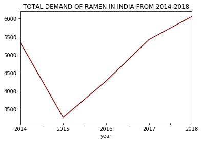

```python
#Total demand in India
year = ["2014","2015","2016","2017","2018"]
demand = [5340, 3260, 4270, 5420, 6060]
india = pd.DataFrame({"year": year, "demand": demand})
india.set_index("year")["demand"].plot(color="maroon")
plt.title("TOTAL DEMAND OF RAMEN IN INDIA FROM 2014-2018")
```

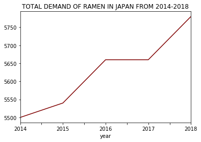

```python
#Total demand in Japan
year = ["2014","2015","2016","2017","2018"]
demand = [5500, 5540, 5660, 5660, 5780]
japan = pd.DataFrame({"year": year, "demand": demand})
japan.set_index("year")["demand"].plot(color="maroon")
plt.title("TOTAL DEMAND OF RAMEN IN JAPAN FROM 2014-2018")
```

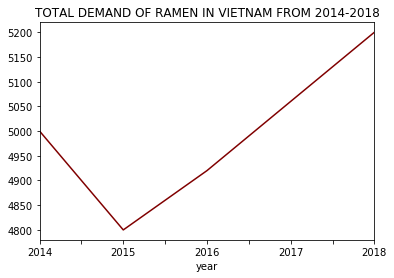

```python
#Total demand in Vietnam
year = ["2014","2015","2016","2017","2018"]
demand = [5000, 4800, 4920, 5060, 5200]
vietnam = pd.DataFrame({"year": year, "demand": demand})
vietnam.set_index("year")["demand"].plot(color="maroon")
plt.title("TOTAL DEMAND OF RAMEN IN VIETNAM FROM 2014-2018")
```

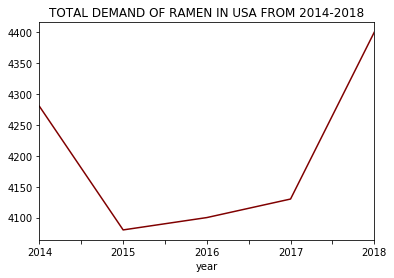

```python
#Total demand in USA
year = ["2014","2015","2016","2017","2018"]
demand = [4280, 4080, 4100, 4130, 4400]
usa = pd.DataFrame({"year": year, "demand": demand})
usa.set_index("year")["demand"].plot(color="maroon")
plt.title("TOTAL DEMAND OF RAMEN IN USA FROM 2014-2018")
```

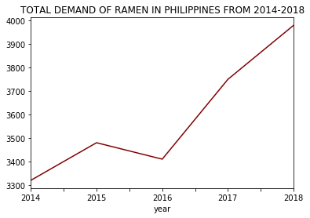

```python
#Total demand in Philippines
year = ["2014","2015","2016","2017","2018"]
demand = [3320, 3480, 3410, 3750, 3980]
philippines = pd.DataFrame({"year": year, "demand": demand})
philippines.set_index("year")["demand"].plot(color="maroon")
plt.title("TOTAL DEMAND OF RAMEN IN PHILIPPINES FROM 2014-2018")
```

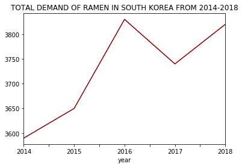

```python
#Total demand in South Korea
year = ["2014","2015","2016","2017","2018"]
demand = [3590, 3650, 3830, 3740, 3820]
southKorea = pd.DataFrame({"year": year, "demand": demand})
southKorea.set_index("year")["demand"].plot(color="maroon")
plt.title("TOTAL DEMAND OF RAMEN IN SOUTH KOREA FROM 2014-2018")
```

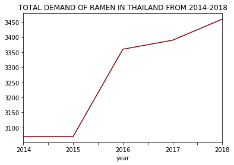

```python
#Total demand in Thailand
year = ["2014","2015","2016","2017","2018"]
demand = [3070, 3070, 3360, 3390, 3460]
thailand = pd.DataFrame({"year": year, "demand": demand})
thailand.set_index("year")["demand"].plot(color="maroon")
plt.title("TOTAL DEMAND OF RAMEN IN THAILAND FROM 2014-2018")
```

# Searching

Option 1: Displaying all information and graphs.

Option 2: Displaying brand, country, and stars.

Option 3: Displaying brand, variety, style, and country.

Option 4: Write to csv file (Please remember to enter .csv at the end)

Option 5: Prediction markets. If the temperature is below or 20 degree Celsius, we predict the customers will buy ramen. If the temperature is above 20 degree Celsius, we predict the customers will not buy ramen.

```python
def function1():
    ask = input("Please enter any country: ")
    c = rf[rf.Country == ask]
    df = pd.DataFrame(c)
    print(df.to_string())
    #style plot
    style = c.Style.value_counts()
    style.plot.pie(autopct="%1.0f%%")
    plt.axis("tight")
    plt.title("STYLES OF RAMEN IN " + ask.upper())
    plt.show()
    #brand plot
    brand = c.Brand.value_counts().head(10)
    brand.plot.barh(color=["steelblue", "orange", "green", "red", "purple", "brown", "pink", "gray", "olive", "cyan"])
    plt.title("TOP 10 BRANDS OF RAMEN IN " + ask.upper())
    plt.show()
    #variety plot
    variety = c.Variety.value_counts().head(10)
    variety.plot.barh(color=["steelblue", "orange", "green", "red", "purple", "brown", "pink", "gray", "olive", "cyan"])
    plt.title("TOP 10 FLAVOR OF RAMEN IN " + ask.upper())
    plt.show()
def function2():
    ask = input("Please enter any country: ")
    c = rf[rf.Country == ask]
    df = pd.DataFrame(c)
    df = df[["Brand", "Country", "Stars"]]
    print(df.to_string())
def function3():
    ask = input("Please enter any country: ")
    c = rf[rf.Country == ask]
    df = pd.DataFrame(c)
    df = df[["Brand", "Variety", "Style", "Country"]]
    print(df.to_string())
def function4():
    ask = input("Please enter any country: ")
    c = rf[rf.Country == ask]
    out = input("Enter the name of the file:")
    df = pd.DataFrame(c)
    df.set_index("Review #", inplace=True)
    df.to_csv(out)
def function5():
    woeid = 0
    t = 0
    #Finding woeid
    query = input("Enter a city: ").strip().replace(" ", "+")
    urlBase = "https://www.metaweather.com/api/location/"
    urlSearch = urlBase + "search?query=" + query
    uh = urllib.request.urlopen(urlSearch)
    data = uh.read().decode()
    js = json.loads(data)
    for k in js:
        woeid = k["woeid"]
        print("woeid: " + str(woeid))
    #Finding date
    date = input("Please enter the date (Format for the date: yyyy/mm/dd): ")
    urlRetrieve = urlBase + str(woeid) + "/" + str(date) + "/"
    uhRetrieve = urllib.request.urlopen(urlRetrieve)
    data2 = uhRetrieve.read().decode()
    js2 = json.loads(data2)
    for k in js2:
        w = k["weather_state_name"]
        t = k["the_temp"]
    print("The temperature on " + str(date) + " is: " + str(t) + " degree Celsius. The weather is " + str(w))
    if t <= 20:
        print("The customers will buy ramen")
    elif t > 20:
        print("The customers will not buy ramen")

if __name__ == "__main__":
    cy = input(" 1: Displaying all infomation and graphs.\n 2: Displaying brand, country, and stars.\n 3: Displaying brand, variety, style, and country.\n 4: Write to csv file.\n 5: Prediction markets.\n Your choice is:  ")
    if cy == "1":
        function1()
    elif cy == "2":
        function2()
    elif cy == "3":
        function3()
    elif cy == "4":
        function4()
    elif cy == "5":
        function5()
```

```
 1: Displaying all infomation and graphs.
 2: Displaying brand, country, and stars.
 3: Displaying brand, variety, style, and country.
 4: Write to csv file.
 5: Prediction markets.
 Your choice is:  4
Please enter any country: Japan
Enter the name of the file:out.csv
```

# Object-oriented programming

```python
#Composition
class Country:
    def __init__(self, name):
        self.name = name
        self.varieties = []

    def add_variety(self, variety):
        self.varieties.append(variety)

class Brand:
    def __init__(self, name):
        self.name = name
        self.flavors = []

    def add_flavor(self, name, style, star):
        variety = Variety(name, style, self, star)
        self.flavors.append(variety)

class Variety:
    def __init__(self, name, style, brand, star):
        self.name = name
        self.style = style
        self.brand = brand
        self.star = star

#Japan
japan_brand = Brand("Sapporo Ichiban")
japan_brand.add_flavor("Chow Mein", "Pack", 5)
japan_brand.add_flavor("Shrimp Flavor", "Pack", 2.5)
japan_brand.add_flavor("Miso Soybean Paste", "Pack", 3.5)
japan = Country("Japan")
for f in japan_brand.flavors:
    japan.add_variety(f)
    print("Country: " + japan.name + " Brand: " + japan_brand.name + " Variety: " + f.name + " Style: " + f.style + " Star: " + str(f.star))

#Singapore
singapore_brand = Brand("Koka")
singapore_brand.add_flavor("Tom Yum Rice Noodles", "Bowl", 3.5)
singapore_brand.add_flavor("Curry", "Pack", 4.25)
singapore_brand.add_flavor("Spicy Seasame", "Pack", 5)
singapore = Country("Singapore")
for f in singapore_brand.flavors:
    singapore.add_variety(f)
    print("Country: " + singapore.name + " Brand: " + singapore_brand.name + " Variety: " + f.name + " Style: " + str(f.style) + " Star: " + str(f.star))
```

```
Country: Japan Brand: Sapporo Ichiban Variety: Chow Mein Style: Pack Star: 5
Country: Japan Brand: Sapporo Ichiban Variety: Shrimp Flavor Style: Pack Star: 2.5
Country: Japan Brand: Sapporo Ichiban Variety: Miso Soybean Paste Style: Pack Star: 3.5
Country: Singapore Brand: Koka Variety: Tom Yum Rice Noodles Style: Bowl Star: 3.5
Country: Singapore Brand: Koka Variety: Curry Style: Pack Star: 4.25
Country: Singapore Brand: Koka Variety: Spicy Seasame Style: Pack Star: 5
```